# “Human Activity Recognition”

“Yiu Chung Wong”

“02 December, 2017”

# Overview

This report explores the Weight Lifting Exercises Dataset and attempt to predict the type of performance based on data from various sensors on the body.

## Data

The training data for this project are available [here](https://d396qusza40orc.cloudfront.net/predmachlearn/pml-training.csv):

The test data are available [here](https://d396qusza40orc.cloudfront.net/predmachlearn/pml-testing.csv):

The data for this project come from [this source](http://web.archive.org/web/20161224072740/http:/groupware.les.inf.puc-rio.br/har). If you use the document you create for this class for any purpose please cite them as they have been very generous in allowing their data to be used for this kind of assignment.

Graphs are placed in the appendix for references. However, code are placed within the main text to show the flow of model development.

### Load data

1. The first document is the dataset for training the model.
2. The second document contains data which we are trying to predict.

```r
#load data from working directory
originalTrain = read.csv(file = "pml-training.csv", header = TRUE)
validation = read.csv(file = "pml-testing.csv", header = TRUE)
```

### Data cleaning

The data are further cleaned by:  
* Removing the first seven fields which are just descriptive data  
* Removing near zero variance fields  
* Removing fields with mostly NA

```r
#Remove the first seven columns
originalTrain <- originalTrain[,-(1:7)]; validation <- validation[,-(1:7)]

#Remove NearZeroVariance variables
nzv <- nearZeroVar(originalTrain,saveMetrics=TRUE)
originalTrain <- originalTrain[,nzv$nzv == FALSE]
validation <- validation[,nzv$nzv == FALSE]

#Clean variables with mostly NA
trainNA <- apply(originalTrain, 2, function(col){sum(is.na(col))/length(col)})
originalTrain <- originalTrain[,which(trainNA < .1)]
validation <- validation[,which(trainNA < .1)]
```

### Pre-processing

The training data set is sliced into 70% for training and 30% for testing

```r
#Data slicing
inTrain <- createDataPartition(y=originalTrain$classe, p=0.70, list=FALSE)
train <- originalTrain[inTrain,]
test <- originalTrain[-inTrain,]
```

### Principal Component Analysis

Reduce the data set while retaining 99% of the information

```r
prComp <- preProcess(train[,-length(train)],method="pca", thresh = 0.99)
trainPC <- predict(prComp, train[,1:ncol(train)-1])
testPC <- predict(prComp, test[,1:ncol(test)-1])
validationPC <- predict(prComp, validation[,1:ncol(validation)-1])
```

## Prediction models

### Decision Tree

First let’s try modelling with Decision tree. In this model, 10 folds are created and used in cross-validation method.

```r
set.seed(54321)
fitControl <- trainControl(method = "cv", number = 10)
modFitDT <- train(x = trainPC, y = train$classe, method="rpart", trControl = fitControl)
```

The predicted out of sample accuracy is 0.3804588. The accuracy is low and we need to fit another model. Please refer to figure 1 in the appendix for the fancy decision tree representation.

### Random Forest

Random Forest should yield a more accurate model. Since RF handles cross validation on the fly, we do not need to specify the number of folds here.

```r
set.seed(54321)
fitControl <- trainControl(allowParallel = TRUE)
modFitRF <- train(x = trainPC, y = train$classe, method="rf",trControl = fitControl)

modFitRF
confusionMatrix(test$classe, predict(modFitRF,testPC))
```

```
## Random Forest
##
## 13737 samples
##    36 predictor
##     5 classes: 'A', 'B', 'C', 'D', 'E'
##
## No pre-processing
## Resampling: Bootstrapped (25 reps)
## Summary of sample sizes: 13737, 13737, 13737, 13737, 13737, 13737, ...
## Resampling results across tuning parameters:
##
##   mtry  Accuracy   Kappa
##    2    0.9684030  0.9600037
##   19    0.9621236  0.9520617
##   36    0.9514429  0.9385358
##
## Accuracy was used to select the optimal model using  the largest value.
## The final value used for the model was mtry = 2.
## Confusion Matrix and Statistics
##
##           Reference
## Prediction    A    B    C    D    E
##          A 1671    3    0    0    0
##          B   27 1100   10    2    0
##          C    2   15 1000    8    1
##          D    0    0   28  934    2
##          E    2    2   12    4 1062
##
## Overall Statistics
##
##                Accuracy : 0.9799
##                  95% CI : (0.976, 0.9834)
##     No Information Rate : 0.2892
##     P-Value [Acc > NIR] : < 2.2e-16
##
##                   Kappa : 0.9746
##  Mcnemar's Test P-Value : NA
##
## Statistics by Class:
##
##                      Class: A Class: B Class: C Class: D Class: E
## Sensitivity            0.9818   0.9821   0.9524   0.9852   0.9972
## Specificity            0.9993   0.9918   0.9946   0.9939   0.9959
## Pos Pred Value         0.9982   0.9658   0.9747   0.9689   0.9815
## Neg Pred Value         0.9926   0.9958   0.9897   0.9972   0.9994
## Prevalence             0.2892   0.1903   0.1784   0.1611   0.1810
## Detection Rate         0.2839   0.1869   0.1699   0.1587   0.1805
## Detection Prevalence   0.2845   0.1935   0.1743   0.1638   0.1839
## Balanced Accuracy      0.9905   0.9870   0.9735   0.9896   0.9965
```

The accuracy of the model is 0.979949. Hence out of sample error = 1 - 0.979949 = 0.020051

## Prediction

```r
predict(modFitRF,validationPC)
```

```
##  [1] B A A A A E D B A A B C B A E E A B B B
## Levels: A B C D E
```

## Summary

The Random Forest model produced stunning accuracy of 0.979949. The results are satisfactory given the chances of correctly predicting all 20 cases in the test dataset is minimal. The Decision Tree model performed poorly and was disgarded.

# Appendix

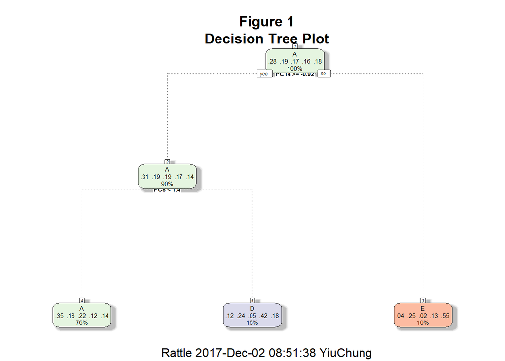